# Analyzing Chick Weights with splinectomeR

### Sliding spline test

```r
result <- sliding_spliner(data = ChickWeight, xvar = 'Time', yvar = 'weight',
                          cases = 'Chick', category = 'Diet', groups = c('1','2'))
```

```
## Running sliding spline test with 100 time points extrapolated from splines...
##
## Groups detected: 1 and 2 .
##
## Data organization successfull;
## ...now testing for significant differences in the response labeled weight
## Splines successfully generated for each case; now testing for significance over 100 intervals
## Testing completed, just organizing the results a bit...
##
## Done! To visualize your results, try the following commands, where "data" is your results object:
## sliding_spliner.plot.splines(data, xvar="Time", yvar="weight", category="Diet")
## or
## sliding_spliner.plot.pvals(data, xvar="Time")
```

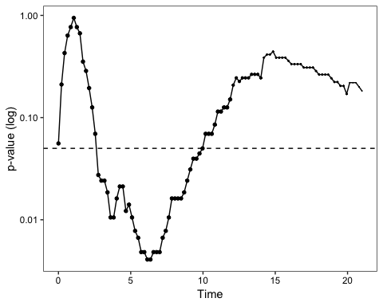

```r
sliding_spliner.plot.pvals(result, xvar = 'Time')
```

The defaul is 100 intervals, but if you have a very long or short timeseries, you might want more or less intervals, respectively. Here you can see what it looks like with just 5 intervals:

```r
result <- sliding_spliner(data = ChickWeight, xvar = 'Time', yvar = 'weight',
                          cases = 'Chick', category = 'Diet', groups = c('1','2'), ints = 5)
```

```
## Running sliding spline test with 5 time points extrapolated from splines...
##
## Groups detected: 1 and 2 .
##
## Data organization successfull;
## ...now testing for significant differences in the response labeled weight
## Splines successfully generated for each case; now testing for significance over 5 intervals
## Testing completed, just organizing the results a bit...
##
## Done! To visualize your results, try the following commands, where "data" is your results object:
## sliding_spliner.plot.splines(data, xvar="Time", yvar="weight", category="Diet")
## or
## sliding_spliner.plot.pvals(data, xvar="Time")
```

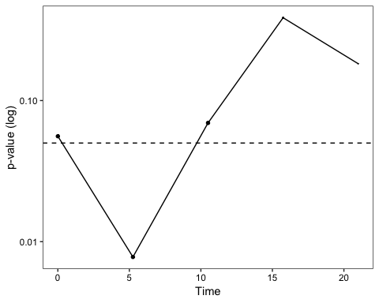

```r
sliding_spliner.plot.pvals(result, xvar = 'Time')
```

There is a line at *p* = 0.05, and the y-axis is log-scaled for visual clarity. You can always make your own plot from the stored results table as well, if this plotting does not fulfill your needs. Here, dots are scaled in size according to the number of original observations that support that interval; that is, the dots become smaller toward the 20 day time point because there are less overall data points in the dataset being used to calculate the splines and resulting p-values there. You can think of it as a quick visual confidence measure.

## Non-zero trends

The third major functionality in the `splinectomeR` package is detecting significant non-zero trends through a permutation test, where the null hypothesis is a trend that doesn’t differ from the group mean. Here, all of the Chicks are growing, so it is reasonable to predict that all of the diets will produce a non-zero trend.

As in the `permuspliner()` test above, you must specify a group to analyze if there are multiple groups.

```r
diet_4_trend <- trendyspliner(data = ChickWeight, xvar = 'Time', yvar = 'weight', group = '4',
                        cases = 'Chick', category = 'Diet', perms = 99, mean_center = F)
```

```
##
## Testing for a non zero trend in weight across Time ...
##
## Performing the trendyspline test with 99 permutations...
## Calculations completed on observed data.
##
##               Now preparing the 99 permutations - this may take some time...
## Permutations completed successfully!
##
## p-value = 0.01
```

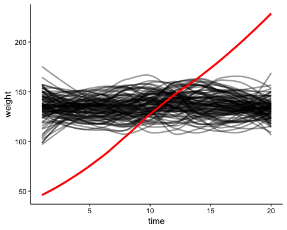

```r
# There is also a plotting function for visualizing the permutations in this function
# Note the x and y label arguments are purely aesthetic
trendyspliner.plot.perms(diet_4_trend, xlabel = 'time', ylabel = 'weight')
```

You could also quickly run through all four diet variables using some other R tricks (using `lapply()` here). We expect each of these diet conditions to have a positive weight trend, since in all cases the chicks are gaining weight:

```r
diets <- c('1','2','3','4')
diet_results <- lapply(X = diets,
                      FUN = function(xx) trendyspliner(data = ChickWeight, xvar = 'Time',
                                                      yvar = 'weight', group = xx,
                                                      cases = 'Chick', category = 'Diet',
                                                      perms = 99, mean_center = F))
```

```
##
## Testing for a non zero trend in weight across Time ...
##
## Performing the trendyspline test with 99 permutations...
## Calculations completed on observed data.
##
##               Now preparing the 99 permutations - this may take some time...
## Permutations completed successfully!
##
## p-value = 0.01
##
##
## Testing for a non zero trend in weight across Time ...
##
## Performing the trendyspline test with 99 permutations...
## Calculations completed on observed data.
##
##               Now preparing the 99 permutations - this may take some time...
## Permutations completed successfully!
##
## p-value = 0.01
##
##
## Testing for a non zero trend in weight across Time ...
##
## Performing the trendyspline test with 99 permutations...
## Calculations completed on observed data.
##
##               Now preparing the 99 permutations - this may take some time...
## Permutations completed successfully!
##
## p-value = 0.01
##
##
## Testing for a non zero trend in weight across Time ...
##
## Performing the trendyspline test with 99 permutations...
## Calculations completed on observed data.
##
##               Now preparing the 99 permutations - this may take some time...
## Permutations completed successfully!
##
## p-value = 0.01
```

## And indeed, that is what we see!

A couple notes and tips about this test: * This test is area-based so it is reasonalby tolerant to non-linear non-zero trends * In some data, the individual cases may have a range of starting points that could confound this trend. For example, measuring changes in many patients’ blood glucose over time: some patients will start out higher than others, but it’s the group trend (up or down vs linear/no change) that is of interest. In these situations you can mean-center the cases prior to analysis with the `mean_center = TRUE` argument. * If your data consists of only one group, you probably do not have a “category” column at all, and you can omit this arguement.